# Lab 08

## Week 08 Lab

### Applied Cryptography (6G6Z0024_2324_9)

### Plan

This builds on last week's public key cryptography problems by adding some Diffie-Hellman and ElGamal problems.

### Lab exercises

A selection of excersises taken from the end of chapter exercises from [Stallings, Chapters 9 and 10, *Public-key cryptography*](https://mmu.on.worldcat.org/oclc/1334132058).

- 9.2 Perform encryption and decryption using the RSA algorithm, as in figure 9.5. for the following parameters
  - a. $p=3; \, q=7; \, e=5; \, M = 10$
  - c. $p=7; \, q=17; \, e=11;\, M=11$

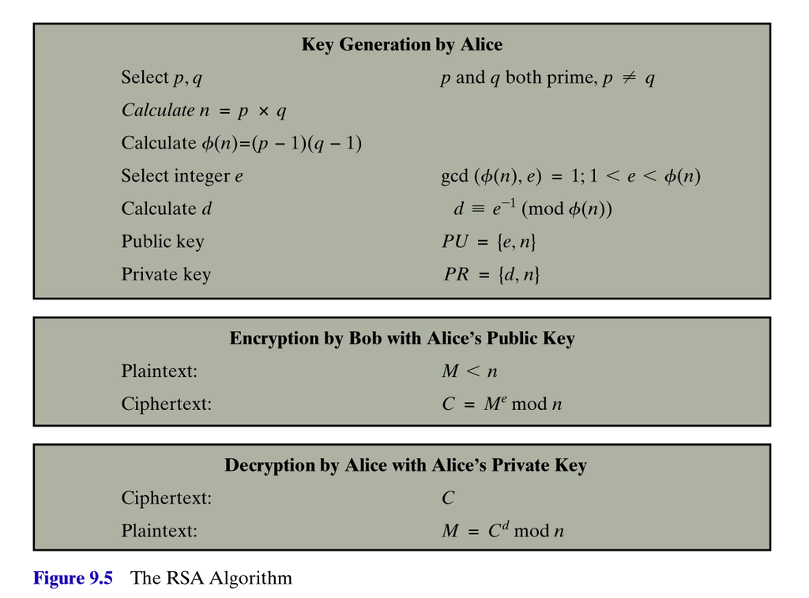

- 9.3 In a public-key system using RSA, you intercept the ciphertext $C=20$ sent to a user whose public key is $e=13, n=77$. What is the plaintext M?
- 9.4 In an RSA system, the public key of a given user is $e=65. n=2881$. What is the private key of this user? *Hint: First use trial and error (or another method) to determine $p$ and $q$, then use the extended Euclidean algorithm to find the required multiplicative inverse of 65 modulo $\phi(n)$*.
- 10.1
- 10.2
- 10.6

Other suggested exercises are 9.5, 9.8, 9.9, 9.13, from Chapter 9 and the investigative problems 10.3, 10.4 and 10.5 from Chapter 10.